# Global CO2 Emissions

Gavin McNicol

2023-01-11

## Introduction

How much carbon dioxide (CO2) do different countries emit, and how have their emissions changed over time? Answering these questions (at a high level) is the focus of this analysis.

### Packages

We will use the R **tidyverse** and **scales** packages for data wrangling and visualization, and the **reactable** package for interactive display of tabular output, and **Global Carbon Project** excel (.xlsx) files for the data.

*Note: Packages are just pre-assembled collections of functions and objects (often data)*

```r
library(tidyverse)
library(scales)
library(reactable)
```

### Data

The data we’re using originally came from the [2020 Global Carbon Budget](https://doi.org/10.5194/essd-12-3269-2020) which is a product of the [Global Carbon Project](https://doi.org/10.18160/gcp-2020).

The data comes in an Excel file called `National_Carbon_Emissions_2020v1.0.xlsx` and has already been added to this exercise folder.

In the code chunk below:

- the first line reads in the data, selects the correct tab `Territorial Emissions`, and removes 11 header rows in the excel file that we don’t need.
- the next line renames the first column `year` from the uninformative column name `...1`.
- the third line rearranges the country emission data for easier plotting.
- the final line converts the `emissions` data column to numerical values.

This code chunk will help you get started with the analysis. **Note: Don’t worry about the details right now!**

```r
emissions <-
  readxl::read_excel("National_Carbon_Emissions_2020v1.0.xlsx", sheet = "Territorial Emissions", skip = 11) %>%
  rename("year" = `...1`) %>%
  gather(key = "territory", value = "emissions", 2:234) %>%
  mutate(emissions = as.numeric(emissions))
```

## Territory CO2 Emissions

Let’s create a data visualization that displays how the CO2 emissions of the **USA** have changed over time, and compare it to two other countries: the **United Kingdom** and **China**.

We can easily change which countries are being plotted by changing which countries the code below `filter`s for.

*Note that the country name should be spelled and capitalized exactly the same way as it appears in the data.*

See the Appendix for a list of the countries in the data.

Next, let’s make the plot:

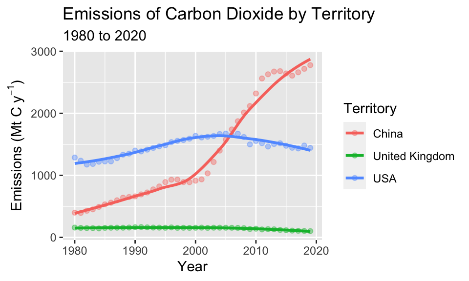

```r
emissions %>%
  filter(territory %in% c("USA", "United Kingdom", "China") &
           year > 1979) %>%
  ggplot(mapping = aes(x = year, y = emissions, color = territory)) +
  geom_point(alpha = 0.4) +
  geom_smooth(method = "loess", se = FALSE) +
  labs(
    title = "Emissions of Carbon Dioxide by Territory",
    subtitle = "1980 to 2020",
    y = expression("Emissions (Mt C y"^{-1}*")"),
    x = "Year",
    color = "Territory"
  )
```

## Exercises

Edit the code in the chunk above to:

1. Visualize an additional territory/territories of your choice.
2. Shorten the x-axis to only show years after 2009.
3. Update the plot subtitle to reflect the shorter time period.
4. Double the size of the entire plot (clue: you may have to “think outside the box”).
5. Finally, edit the `YAML` (document metadata) so that it shows **your name** instead of `Gavin McNicol`.

*Remember to `Knit` the file when you make a change. This will save your work and create an .html output file.*

## References

1. Global Carbon Project. (2020). Supplemental data of Global Carbon Budget 2020 (Version 1.0) [Data set]. [Global Carbon Project](https://doi.org/10.18160/gcp-2020)
2. This exercise was modeled after the UN Votes application exercise in [Data Science in a Box](https://datasciencebox.org/index.html).

## Appendix

Below is a list of countries in the dataset:

| territory |
| --- |
| Afghanistan |
| Albania |
| Algeria |
| Andorra |
| Angola |
| Anguilla |
| Antigua and Barbuda |
| Argentina |
| Armenia |
| Aruba |

[output cut: 223 more lines]